# Exploratory Data Analysis

Bryan Z

2024-09-23

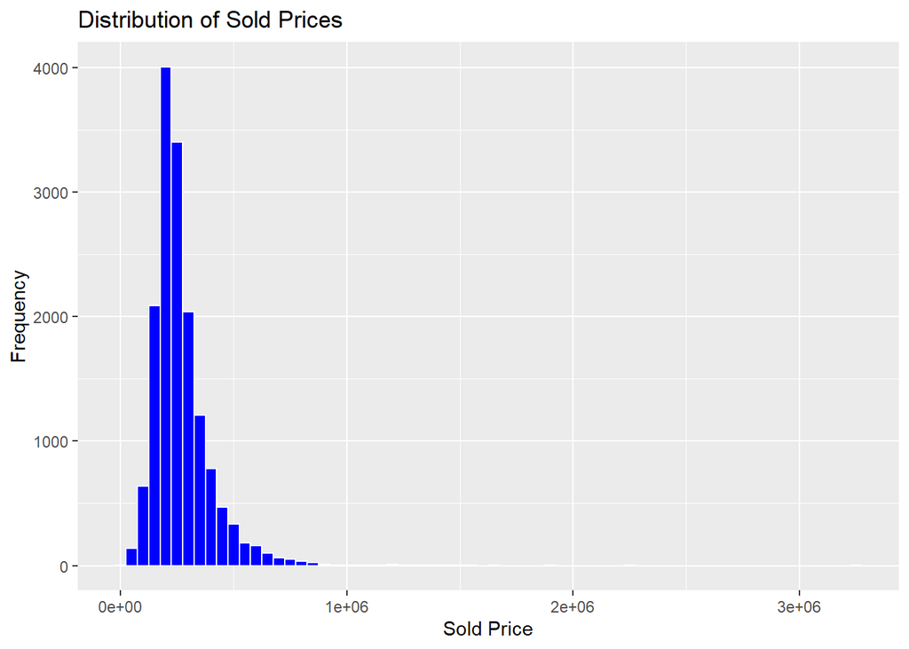

First Guesses on Possible Variables

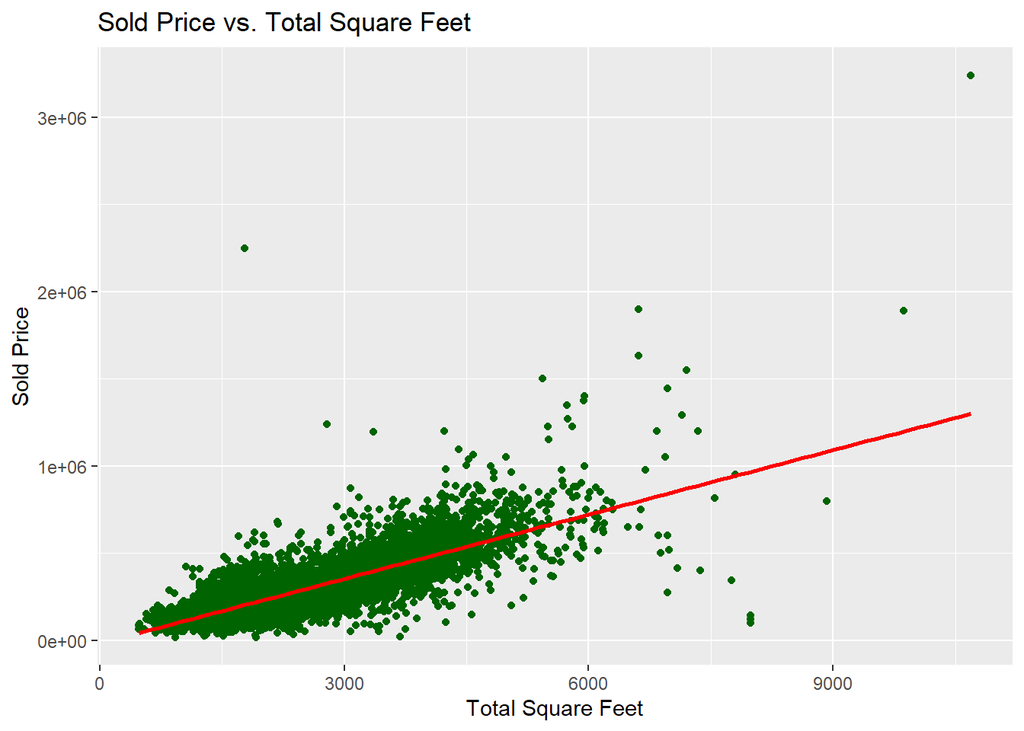

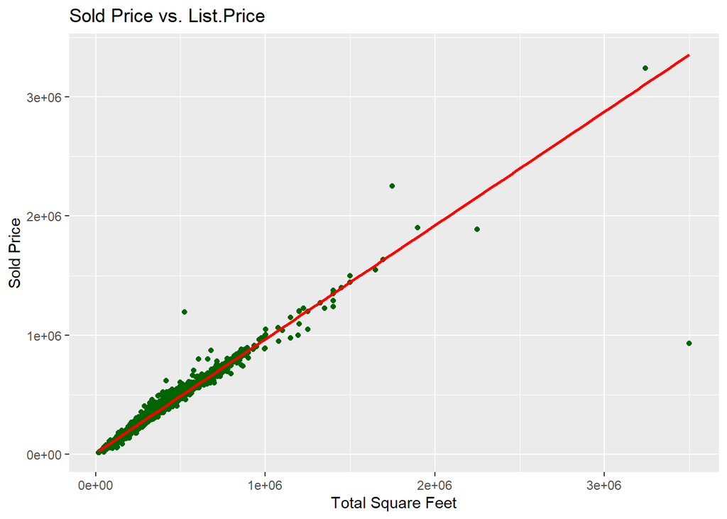

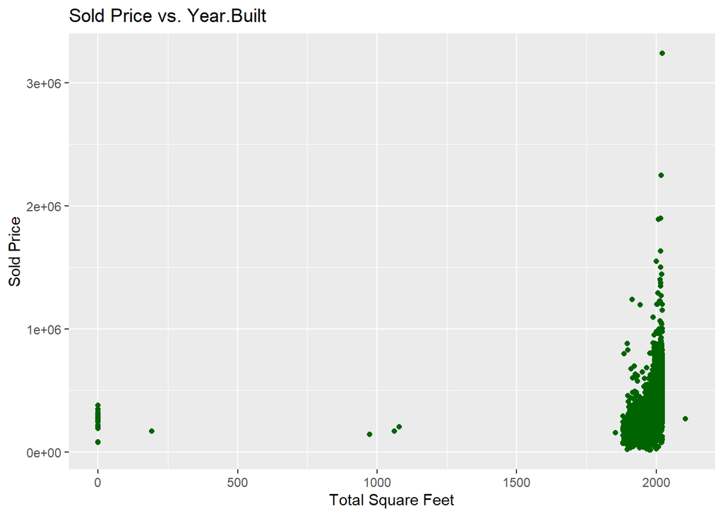

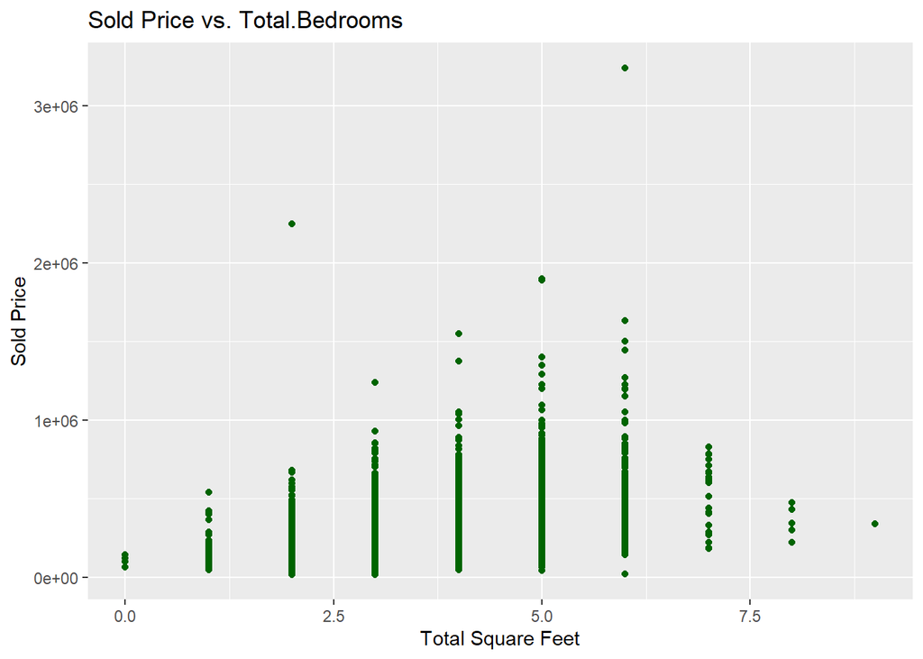

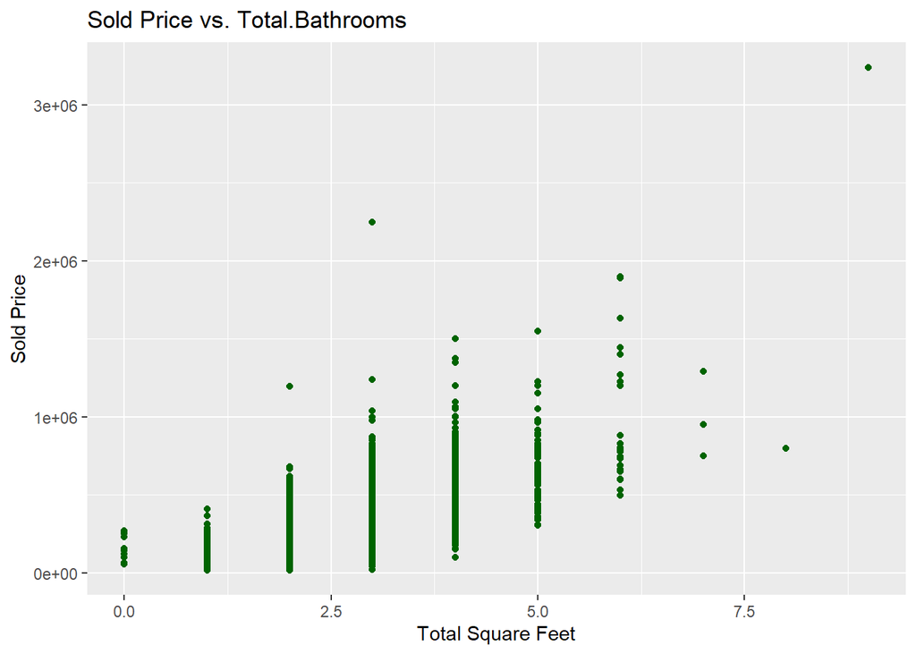

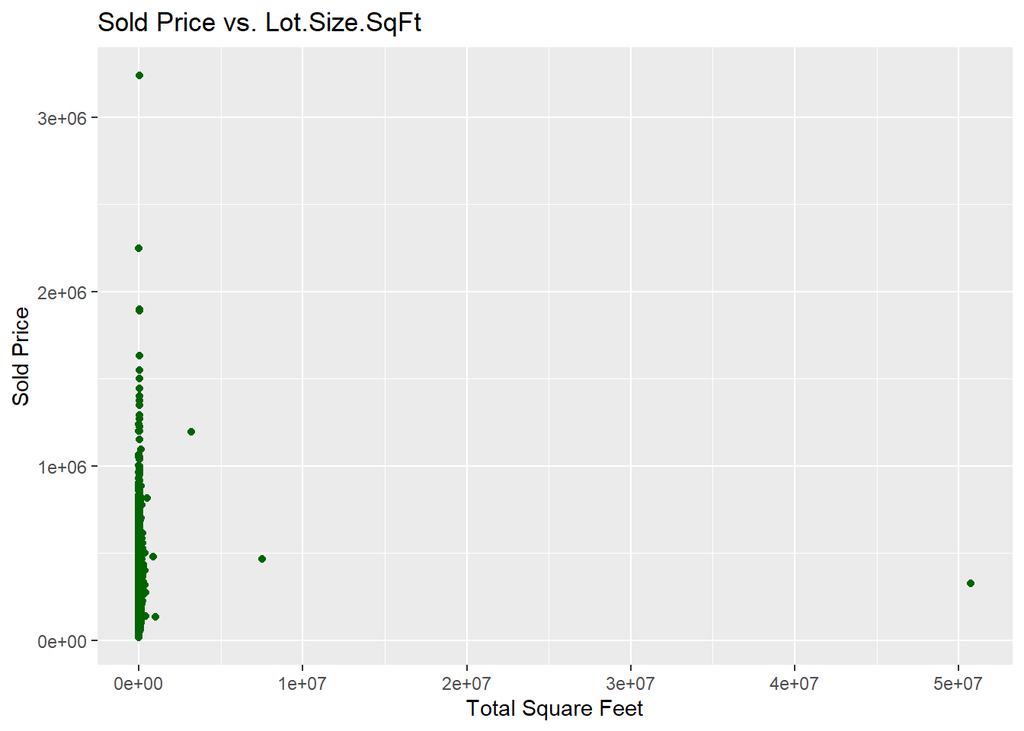

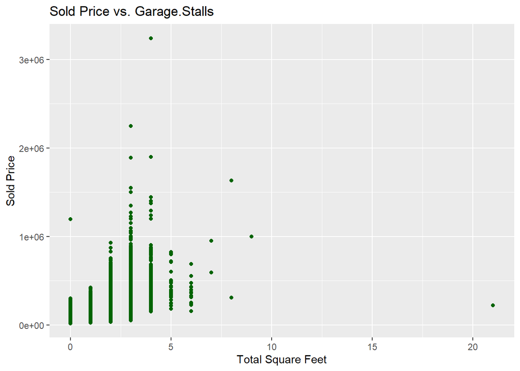

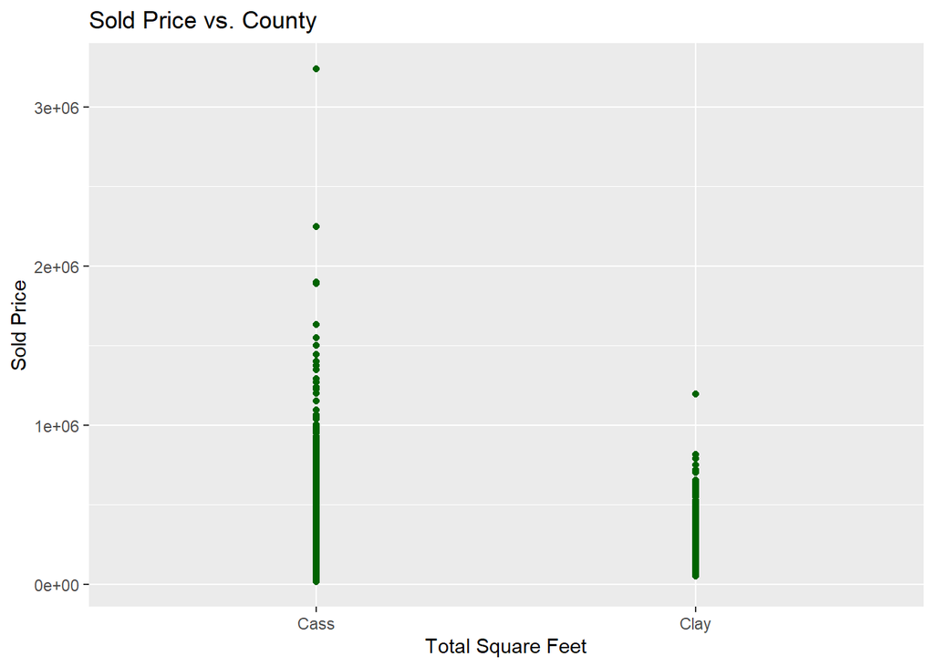

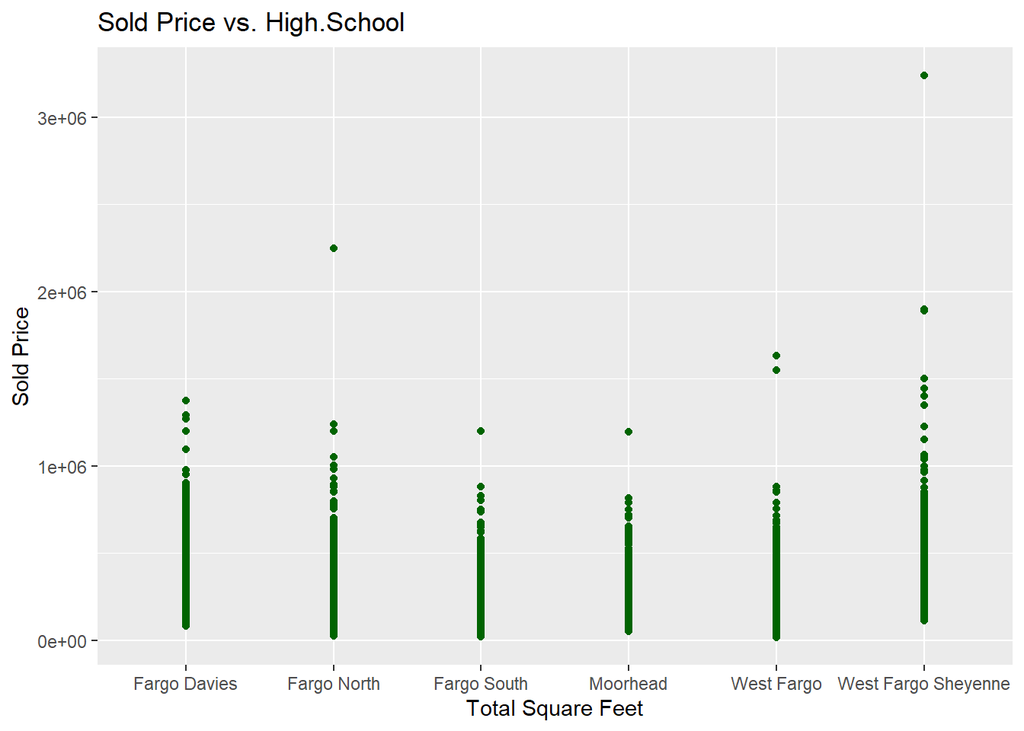

*Train and Test Dataset*

```r
set.seed(42)
test_index <- createDataPartition(housing_data$Sold.Price, p = 0.20, list = FALSE)
test_set <- housing_data[test_index,]
train_set <- housing_data[-test_index,]
```

*Selecting Features - Preliminary Model*

```r
full_model <- lm(Sold.Price ~ List.Price + Total.SqFt. + Year.Built + Total.Bedrooms +
            Total.Bathrooms + Lot.Size.SqFt + Garage.Stalls + County + High.School, data = train_set)

#summary(full_model)
```

*Choosing the Final Model*

```r
# Stepwise regression (both directions)
stepwise_model <- stepAIC(full_model, direction = "both")
```

```
## Start:  AIC=256142.7
## Sold.Price ~ List.Price + Total.SqFt. + Year.Built + Total.Bedrooms +
##     Total.Bathrooms + Lot.Size.SqFt + Garage.Stalls + County +
##     High.School
##
##                   Df  Sum of Sq        RSS    AIC
## - County           1 1.1495e+09 8.2952e+12 256142
## - Lot.Size.SqFt    1 1.2530e+09 8.2954e+12 256143
## <none>                          8.2941e+12 256143
## - Year.Built       1 2.4643e+09 8.2966e+12 256144
## - Total.Bedrooms   1 2.9097e+09 8.2970e+12 256145
## - Total.Bathrooms  1 9.9800e+09 8.3041e+12 256156
## - Garage.Stalls    1 8.2085e+10 8.3762e+12 256265
## - High.School      5 1.0786e+11 8.4020e+12 256296
## - Total.SqFt.      1 1.0843e+11 8.4025e+12 256305
## - List.Price       1 5.4237e+13 6.2531e+13 281623
##
## Step:  AIC=256142.4
## Sold.Price ~ List.Price + Total.SqFt. + Year.Built + Total.Bedrooms +
##     Total.Bathrooms + Lot.Size.SqFt + Garage.Stalls + High.School
##
##                   Df  Sum of Sq        RSS    AIC
## - Lot.Size.SqFt    1 1.2519e+09 8.2965e+12 256142
## <none>                          8.2952e+12 256142
## + County           1 1.1495e+09 8.2941e+12 256143
## - Year.Built       1 2.3781e+09 8.2976e+12 256144
## - Total.Bedrooms   1 2.9221e+09 8.2982e+12 256145
## - Total.Bathrooms  1 1.0063e+10 8.3053e+12 256156
## - Garage.Stalls    1 8.2155e+10 8.3774e+12 256265
## - Total.SqFt.      1 1.0822e+11 8.4035e+12 256304
## - High.School      5 1.2340e+11 8.4186e+12 256319
## - List.Price       1 5.4251e+13 6.2546e+13 281623
##
## Step:  AIC=256142.3
## Sold.Price ~ List.Price + Total.SqFt. + Year.Built + Total.Bedrooms +
##     Total.Bathrooms + Garage.Stalls + High.School
##
##                   Df  Sum of Sq        RSS    AIC
## <none>                          8.2965e+12 256142
## + Lot.Size.SqFt    1 1.2519e+09 8.2952e+12 256142
## + County           1 1.1484e+09 8.2954e+12 256143
## - Year.Built       1 2.3756e+09 8.2989e+12 256144
## - Total.Bedrooms   1 2.8783e+09 8.2994e+12 256145
## - Total.Bathrooms  1 1.0124e+10 8.3066e+12 256156
## - Garage.Stalls    1 8.1992e+10 8.3785e+12 256264
## - Total.SqFt.      1 1.0816e+11 8.4047e+12 256304
## - High.School      5 1.2316e+11 8.4197e+12 256318
## - List.Price       1 5.4271e+13 6.2568e+13 281626
```

```r
# Display the final stepwise model summary
#summary(stepwise_model)
```

From these Step-Wise Regression Model, the following variables are recommended as *good predictors*:

List.Price | Total.SqFt. | Year.Built | Total.Bedrooms | Total.Bathrooms | Garage.Stalls | High.School |

County and Lot.Size.SqFt are not included in this final model.

Therefore, a final model would look like this:

*Final Model*

```r
final_model <- lm(formula = Sold.Price ~ List.Price + Total.SqFt. + Year.Built +
    Total.Bedrooms + Total.Bathrooms + Garage.Stalls + High.School,
    data = train_set)

summary(final_model)
```

```
##
## Call:
## lm(formula = Sold.Price ~ List.Price + Total.SqFt. + Year.Built +
##     Total.Bedrooms + Total.Bathrooms + Garage.Stalls + High.School,
##     data = train_set)
##
## Residuals:
##      Min       1Q   Median       3Q      Max
## -2209167    -6662    -1028     4957   704753
##
## Coefficients:
##                                  Estimate Std. Error t value Pr(>|t|)
## (Intercept)                    -8.819e+03  5.721e+03  -1.542   0.1232
## List.Price                      8.840e-01  3.079e-03 287.116  < 2e-16 ***
## Total.SqFt.                     6.811e+00  5.314e-01  12.818  < 2e-16 ***
## Year.Built                      5.387e+00  2.836e+00   1.900   0.0575 .
## Total.Bedrooms                  6.994e+02  3.345e+02   2.091   0.0366 *
## Total.Bathrooms                 1.719e+03  4.383e+02   3.921 8.85e-05 ***
## Garage.Stalls                   4.511e+03  4.043e+02  11.160  < 2e-16 ***
## High.SchoolFargo North         -7.772e+03  9.330e+02  -8.330  < 2e-16 ***
## High.SchoolFargo South         -6.214e+03  8.605e+02  -7.222 5.44e-13 ***
## High.SchoolMoorhead            -6.005e+03  7.920e+02  -7.582 3.63e-14 ***
## High.SchoolWest Fargo          -4.278e+03  8.841e+02  -4.839 1.32e-06 ***
## High.SchoolWest Fargo Sheyenne  1.824e+03  7.816e+02   2.334   0.0196 *
## ---
## Signif. codes:  0 '***' 0.001 '**' 0.01 '*' 0.05 '.' 0.1 ' ' 1
##
## Residual standard error: 25660 on 12602 degrees of freedom
## Multiple R-squared:  0.9613, Adjusted R-squared:  0.9613
## F-statistic: 2.847e+04 on 11 and 12602 DF,  p-value: < 2.2e-16
```

*Model Performance Evaluation*

R-squared (96.13%): The model explains a large proportion of the variance in Sold.Price. This high R² suggests that the model is fitting the data well.

Residuals: The large residuals (Min: -2,209,167, Max: 704,753) suggest that while the model performs well overall, there are some extreme cases where the predictions are far from the actual values. This could be due to outliers in the data or limitations in the linear model.

Standard Error: The residual standard error of 25,660 is somewhat large, which could imply there are large deviations in certain cases. This could be acceptable depending on the overall price range in your dataset.

*Generating predictions*

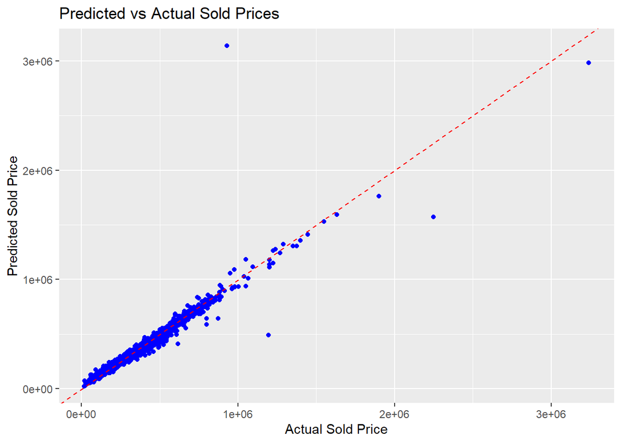